# Are intra and inter chromosomal trans hits occurring at the same rate?

```r
suppressWarnings(suppressPackageStartupMessages({
    library(knitr)
    library(dplyr)
}))
opts_chunk$set(cache=TRUE, echo=TRUE, message=FALSE, warning=FALSE)
```

We have a 1mb radius defining cis. If a trans hit is 1-6mb away, is that as common as something 6-11mb, or in any 5mb region on another chromosome?

Only analyse significant cis and trans hits, and remove chr 6 for simplicity

```r
load("../results/16/16_clumped.rdata")
sig <- subset(clumped,
    (cis & pval < 1e-8) | (!cis & pval < 1e-14)
)
sig <- subset(sig, cpgchr != "chr6" & snpchr != "chr6")
index <- sig$cpgchr == sig$snpchr
sig$cisdist <- NA
sig$cisdist[index] <- abs(sig$cpgpos - sig$snppos)[index]
```

Distribution of distance from cpg for cis

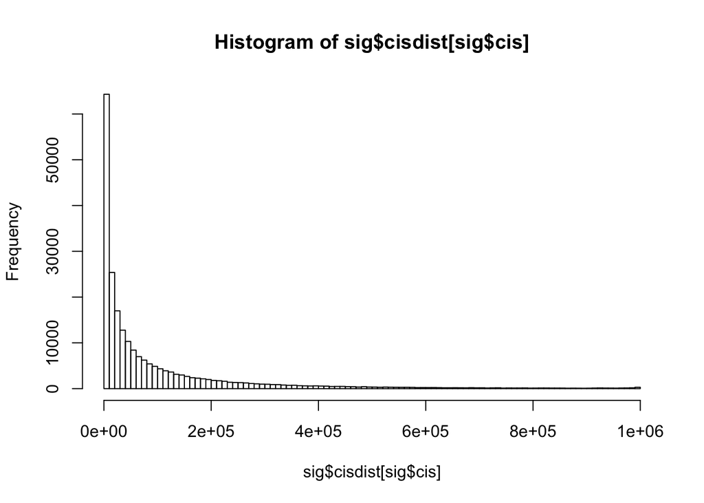

```r
hist(sig$cisdist[sig$cis], breaks=100)
```

Distribution in 5 mb region

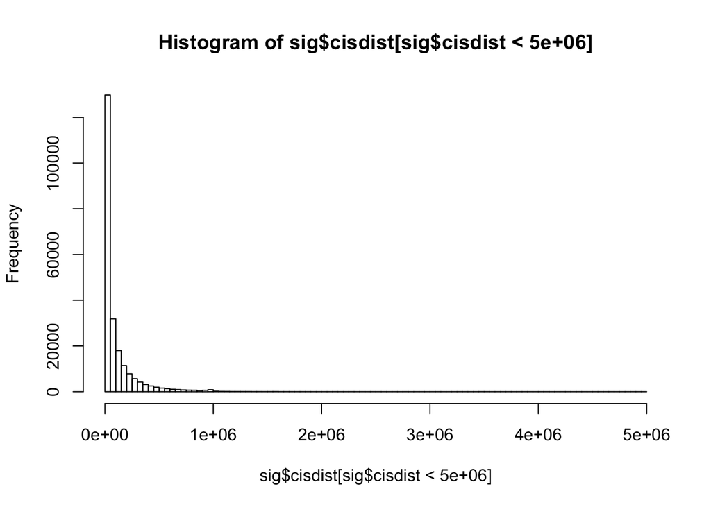

```r
hist(sig$cisdist[sig$cisdist < 5000000], breaks=100)
```

Question: is the 1mb - 6mb region containing more trans than 6mb-11mb

```r
sum(!is.na(sig$cisdist[sig$cisdist > 1000000 & sig$cisdist <= 6000000]))
```

```
## [1] 1437
```

```r
sum(!is.na(sig$cisdist[sig$cisdist > 6000000 & sig$cisdist <= 11000000]))
```

```
## [1] 174
```

How often are CpGs close to the chromosome boundary? Note that there will be more CpGs unable to have a further trans effect because of chromosome boundaries

```r
chromsizes <- read.table("chromosome_sizes.txt", header=TRUE, stringsAsFactors=FALSE)
chromsizes$chrsize / 1000000
```

```
##  [1] 249.25062 243.19937 198.02243 191.15428 180.91526 171.11507 159.13866
##  [8] 155.27056 146.36402 141.21343 135.53475 135.00652 133.85190 115.16988
## [15] 107.34954 102.53139  90.35475  81.19521  78.07725  63.02552  59.37357
## [22]  59.12898  51.30457  48.12989
```

```r
# What is the size of the inter chromosomal region for each mQTL?
chromsizes$inter_size <- sum(chromsizes$chrsize) - chromsizes$chrsize

sig <- merge(sig, chromsizes, by.x="cpgchr", by.y="chr")
sapply(c(1:11) * 1000000, function(x)
{
    sum((sig$cpgpos - x) < 0 | (sig$cpgpos + x) > sig$chrsize ) / nrow(sig)
})
```

```
##  [1] 0.06101139 0.13507090 0.17972707 0.21610114 0.24433653 0.26490861
##  [7] 0.28533317 0.30358167 0.32447340 0.34005409 0.35721252
```

Restrict only to CpGs that are within the relevant window

```r
# sum((sig$cpgpos - 6000000) > 0 & (sig$cpgpos + 6000000) < sig$chrsize)
# sum((sig$cpgpos - 11000000) > 0 & (sig$cpgpos + 11000000) < sig$chrsize)

sum(
    (sig$cpgpos - 6000000) >= 0 &
    (sig$cpgpos + 6000000) <= sig$chrsize &
    (sig$cisdist > 1000000 & sig$cisdist <= 6000000),
    na.rm=TRUE
)
```

```
## [1] 1321
```

```r
sum(
    (sig$cpgpos - 11000000) >= 0 &
    (sig$cpgpos + 11000000) <= sig$chrsize &
    (sig$cisdist > 6000000 & sig$cisdist <= 11000000),
    na.rm=TRUE
)
```

```
## [1] 143
```

Question: is the intra-chromosomal trans region containing more trans hits than inter chromosomal regions.

```r
p1 <- subset(sig, cpgchr == snpchr & abs(cpgpos - snppos) > 1000000) %>%
    group_by(cpgchr) %>%
    summarise(
        n=n(),
        intra_size=first(chrsize),
        prop=n/(intra_size / 5000000)
    ) %>%
    summarise(m= sum(prop*n) / sum(n)) %>%
    unlist()

p2 <- subset(sig, cpgchr == snpchr & abs(cpgpos - snppos) > 6000000) %>%
    group_by(cpgchr) %>%
    summarise(
        n=n(),
        intra_size=first(chrsize),
        prop=n/(intra_size / 5000000)
    ) %>%
    summarise(m= sum(prop*n) / sum(n)) %>%
    unlist()

p3 <- subset(sig, cpgchr != snpchr) %>%
    group_by(cpgchr) %>%
    summarise(
        n=n(),
        inter_size=first(inter_size),
        prop=n/(inter_size / 5000000)
    ) %>%
    summarise(m= sum(prop*n) / sum(n)) %>%
    unlist()
```

Number of trans mQTLs per 5mb region when:

- More than 1mb away on the same chromosome: 7.9486154
- More than 6mb away on the same chromosome: 4.8149842
- On a different chromosome: 1.5907331